# Gráficos Interactivos

**Juan David Velásquez Henao**  
jdvelasq@unal.edu.co  
Universidad Nacional de Colombia, Sede Medellín  
Facultad de Minas  
Medellín, Colombia

Haga click [aquí](https://github.com/jdvelasq/Python-for-descriptive-analytics/tree/master/) para acceder al repositorio online.

Haga click [aquí](http://nbviewer.jupyter.org/github/jdvelasq/Python-for-descriptive-analytics/tree/master/) para explorar el repositorio usando `nbviewer`.

# Plot.ly

> [plotly](https://plot.ly)

`plotly` es una plataforma web colaborativa para la visualización y el análisis de datos.

Para poder instalar la librería debe ejecutar el siguiente comando:

```python
%%sh
pip install plotly
```

El sitio web ofrece ejemplos y material sobre el uso de la librería.

Ejecute el siguiente ejemplo para verificar que la librería funciona correctamente.

```python
# importa la librería
import plotly
plotly.__version__  # imprime la versión instalada de plotly
```

```
'2.0.14'
```

```python
# importa las librerias para graficación
import plotly.plotly as py
import plotly.tools as tls
```

Para poder usar plotly, es necesario crear una cuenta gratuita en plot.ly. Una vez creada la cuenta, se debe obtener el api_key personal.

En el siguiente paso, se procede al loggin en plotly.

```python
# py.sign_in('your_username','your_api_key')
py.sign_in('jdvelasq','lal1fddnot')
```

```python
# se generan datos para producir la gráfica.
x1 = [1, 2, 3, 5, 6]
y1 = [1, 4.5, 7, 24, 38]
trace1 = dict(x=x1, y=y1)
data = [trace1]
```

```python
# Se hace el gráfico.
py.plot(data, filename='myplot')
```

```
'https://plot.ly/~jdvelasq/2'
```

El último comando genera la visualización de los datos en el sitio web de plotly. En el navegador de internet debe aparecer una pestaña como la siguiente:

[figure not shown]

# Bokeh

Bokeh es una librería para graficación desarrollada por [Continuum Analytics](https://www.continuum.io). El tutorial de Bokeh puede consultarse en el sitio oficial de la herramienta, cuyo vínculo está suministrado en la bibiografía.

En este tutorial se presenta un gráfico en Bokeh que tiene como fin probar que la librería está correctamente instalada.

```python
# El primer paso consiste en importar las librerias en Jupyter.
import numpy as np
from bokeh.plotting import figure, output_file, show
from bokeh.io import output_notebook
```

```python
output_notebook()
```

```python
# se generan puntos aleatorios
N = 4000
x = np.random.random(size=N) * 100
y = np.random.random(size=N) * 100
radii = np.random.random(size=N) * 1.5
colors = [
    "#%02x%02x%02x" % (int(r), int(g), 150) for r, g in zip(50+2*x, 30+2*y)
]
```

```python
# genera la figura, grafica los puntos y visualiza la gráfica
p = figure(x_range=(0,100), y_range=(0,100))
p.circle(x,y, radius=radii, fill_color=colors, fill_alpha=0.6, line_color=None)
show(p)
```

[interactive chart not shown]

# Seaborn

> [Seaborn](https://web.stanford.edu/~mwaskom/software/seaborn/) by Michael Waskom.

Seaborn es una librería para la visualización de datos estadísticos desarrollada en matplotlib por M. Waskom. El sitio web indicado en la bibliografía contiene información detallada incluyendo la [guía de instalación](https://web.stanford.edu/~mwaskom/software/seaborn/installing.html#installing), [notas introductorias](https://web.stanford.edu/~mwaskom/software/seaborn/introduction.html#introduction), un tutorial y el [manual de referencia](https://web.stanford.edu/~mwaskom/software/seaborn/api.html#api-ref).

A continuación se realiza un gráfico (del tutorial) en Jupyter para verificar que `seaborn` funciona correctamente.

```python
%%sh
conda install seaborn
```

[output not shown]

```python
# Se procede igual que cuando se realizan gráficos en matplotlib.
import matplotlib.pyplot as plt
import numpy as np

# para que los gráficos se hagan en línea.
%matplotlib inline

# se generan los puntos aleatorios.
x = np.random.normal(size=100)
```

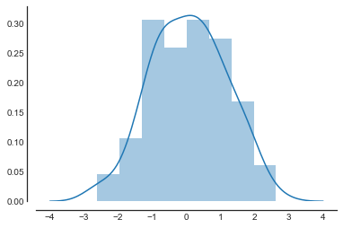

```python
# se importa la librería.
import seaborn as sns
sns.set_style("white") # se quita la malla (grid).
sns.distplot(x)        # distribution plot (histograma)
sns.despine(offset=10) # se modifican los ejes
```